# Take Home Exam - Intro to Predictive Modelling

### Problem 1 : Beauty Problem

```r
raw_data <- read.csv("BeautyData.csv")

## Checking the summary of the data
summary(raw_data)
```

```
##   CourseEvals     BeautyScore           female           lower
##  Min.   :1.944   Min.   :-1.53884   Min.   :0.0000   Min.   :0.0000
##  1st Qu.:3.326   1st Qu.:-0.74462   1st Qu.:0.0000   1st Qu.:0.0000
##  Median :3.682   Median :-0.15636   Median :0.0000   Median :0.0000
##  Mean   :3.689   Mean   :-0.08835   Mean   :0.4212   Mean   :0.3391
##  3rd Qu.:4.067   3rd Qu.: 0.45725   3rd Qu.:1.0000   3rd Qu.:1.0000
##  Max.   :5.000   Max.   : 1.88167   Max.   :1.0000   Max.   :1.0000
##    nonenglish       tenuretrack
##  Min.   :0.00000   Min.   :0.0000
##  1st Qu.:0.00000   1st Qu.:1.0000
##  Median :0.00000   Median :1.0000
##  Mean   :0.06048   Mean   :0.7797
##  3rd Qu.:0.00000   3rd Qu.:1.0000
##  Max.   :1.00000   Max.   :1.0000
```

```r
## Plotting courseevals and beautyscore
train <- raw_data[,1:2]
k <- lm(BeautyScore ~ CourseEvals,train)
summary(k)
```

```
##
## Call:
## lm(formula = BeautyScore ~ CourseEvals, data = train)
##
## Residuals:
##      Min       1Q   Median       3Q      Max
## -1.74275 -0.54333 -0.08121  0.44552  2.04700
##
## Coefficients:
##             Estimate Std. Error t value Pr(>|t|)
## (Intercept) -2.34054    0.23773  -9.846   <2e-16 ***
## CourseEvals  0.61045    0.06379   9.569   <2e-16 ***
## ---
## Signif. codes:  0 '***' 0.001 '**' 0.01 '*' 0.05 '.' 0.1 ' ' 1
##
## Residual standard error: 0.7211 on 461 degrees of freedom
## Multiple R-squared:  0.1657, Adjusted R-squared:  0.1639
## F-statistic: 91.57 on 1 and 461 DF,  p-value: < 2.2e-16
```

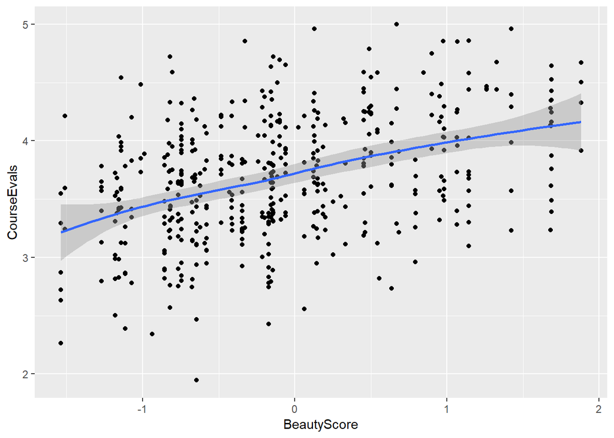

```r
library(ggplot2)

ggplot(train, aes(x=BeautyScore, y=CourseEvals)) + geom_point() + geom_smooth()
```

```r
## Identifying the correlation between courseevaluations and beauty scores
cor(raw_data$CourseEvals,raw_data$BeautyScore)
```

```
## [1] 0.4070912
```

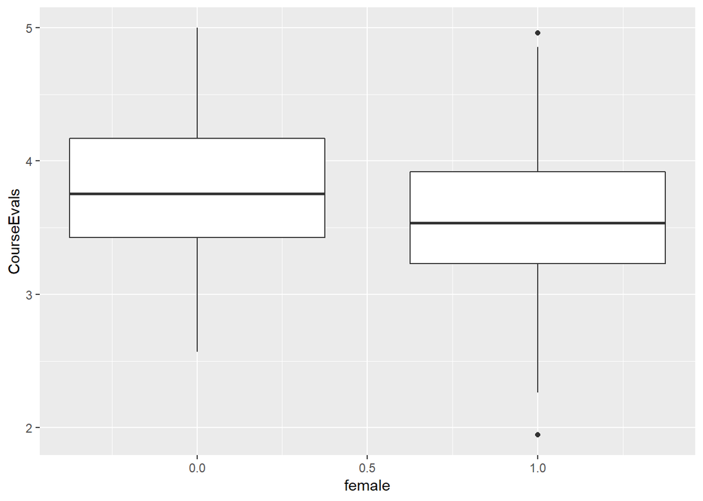

```r
## Gender has an effect on the course evaluation scores
ggplot(raw_data, aes(x=female, y=CourseEvals, group = female)) + geom_boxplot()
```

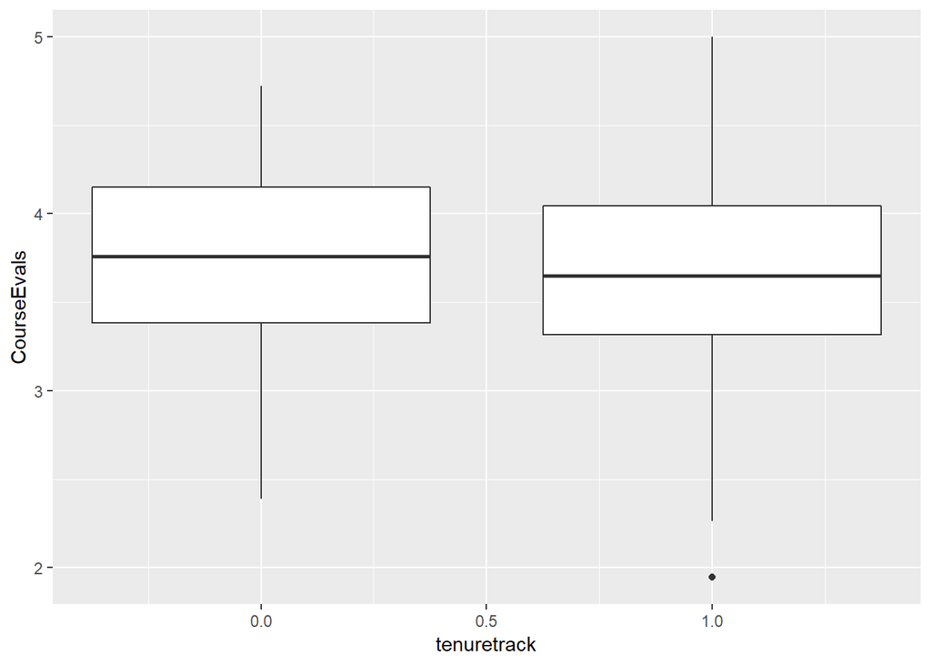

```r
ggplot(raw_data, aes(x=tenuretrack, y=CourseEvals, group = tenuretrack)) + geom_boxplot()
```

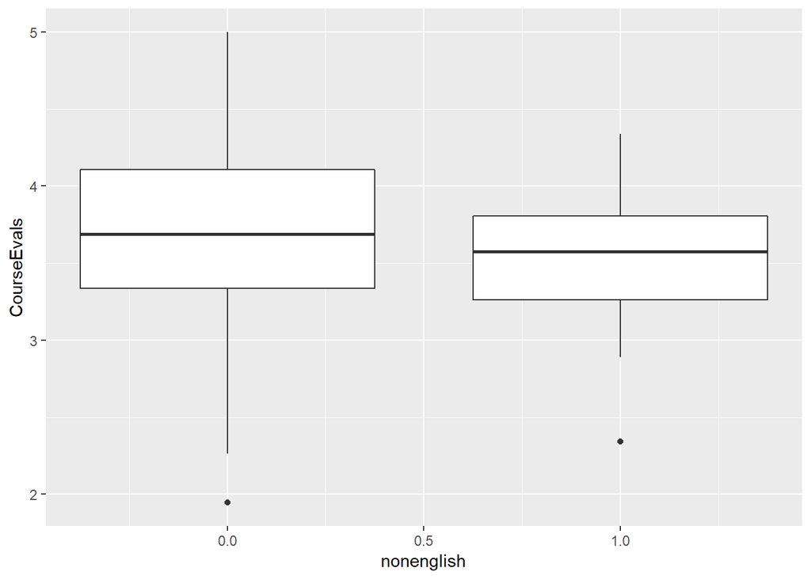

```r
ggplot(raw_data, aes(x=nonenglish, y=CourseEvals, group = nonenglish)) + geom_boxplot()
```

#### b  
#### It is impossible to accurately identify the effect of beauty on income.Skills and strengths of different people vary at different levels.It is quite difficult to keep the other factors constant while measuring the effect of beauty on the income.As teh measurement is based on humans, there are multipe subjective choices that are made based on the situation and type of job.Sometimes it is discrinimatory to say that a person got a job just because he/she is beautiful when he/she is equally talented than any other applicant for the job.Hence it is quite challenging to distinguish between productivity and discrimation in this regard.

### Problem: 2:Housing Price Structure

1. Is there a premium for brick houses everything else being equal?
- Yes there is a premium of $12093.05 if it is a brick house
2. Is there a premium for houses in neighborhood 3?
- Yes there is a premium of $16980 if it is nbhd 3
3. Is there an extra premium for brick houses in neighborhood 3?
- Yes, there is an extra premium of $11933
4. For the purposes of prediction could you combine the neighborhoods 1 and 2 into a single older neighborhood?
- Yes we can combine neighborhood 1 adn 2 as they there is not much difference in the premium and the data shows that the nieghborhood 2 is not even statistically significant

```r
set.seed(4)
midcity = read.csv('MidCity.csv')
# Treating the data
#1.Drop the home variable as it is an index
midcity1 = midcity[,-1]
#2. Change the nbhd variable as a factor variable
midcity1$Nbhd = as.factor(midcity1$Nbhd)
housing.fit = lm(midcity1$Price ~.,midcity1)
#3. Create an interaction term between brick house and nbhd
housing.fit.inter = lm(midcity1$Price ~ Nbhd+Offers+SqFt+Brick+Bedrooms+Bathrooms+Brick*Nbhd,midcity1)
summary(housing.fit.inter)
```

```
##
## Call:
## lm(formula = midcity1$Price ~ Nbhd + Offers + SqFt + Brick +
##     Bedrooms + Bathrooms + Brick * Nbhd, data = midcity1)
##
## Residuals:
##      Min       1Q   Median       3Q      Max
## -27225.1  -5219.0   -273.7   4297.4  27507.2
##
## Coefficients:
##                 Estimate Std. Error t value Pr(>|t|)
## (Intercept)     3695.511   8829.382   0.419  0.67631
## Nbhd2          -1317.656   2679.849  -0.492  0.62385
## Nbhd3          16980.797   3437.529   4.940 2.60e-06 ***
## Offers         -8381.770   1068.248  -7.846 2.15e-12 ***
## SqFt              53.745      5.686   9.453 3.96e-16 ***
## BrickYes       12093.056   4082.168   2.962  0.00369 **
## Bedrooms        4777.216   1586.397   3.011  0.00318 **
## Bathrooms       6457.287   2160.867   2.988  0.00341 **
## Nbhd2:BrickYes  2668.449   5068.893   0.526  0.59957
## Nbhd3:BrickYes 11933.197   5341.027   2.234  0.02735 *
## ---
## Signif. codes:  0 '***' 0.001 '**' 0.01 '*' 0.05 '.' 0.1 ' ' 1
##
## Residual standard error: 9847 on 118 degrees of freedom
## Multiple R-squared:  0.8752, Adjusted R-squared:  0.8657
## F-statistic: 91.94 on 9 and 118 DF,  p-value: < 2.2e-16
```

### Problem 3 : What causes what??

#### 1.

#### Washington D.C has a terror alert system which can be used to establish the causality between cops and crime but the other cities might or might not have it.By running a regression on crime and cops in other cities, we might end up proving the correlation between them but not the causation

#### 2.

#### Researchers at Upenn used the terror alert system in Washington D.C to establish the causation. During the terror alert days, there are generally more cops deployed onto the streets. By comparing the correlation results between crime and cops, the researchers are able to conclude a causal relation between cops and crime.

#### From table 2,given the metro ridership is kept constant, the effect of high alert on crime is fairly constant.But we can clearly see that more the number of people on roads ,higher the crime rate.Also, introduction of metro ridership did not add much information as on high alert, it does not have a considerable effect

#### 3.

#### Also, there was a hypothesis that the terror alert might be causing people not to come outside and the crimes might have dropped because there were less victims to fall prey. But the researchers used the metro ridership data to check if there is any decline in ridership on a terror alert which turned out that the ridership was fairly same when compared to normal days.

#### 4. In this model, the author was trying to show the interaction between high alert and the districts. There was a considerable between high alert and district 1 because additional police will be deployed on high alert days.But that might not be the case in other districts resulting in poor interaction between high alert and other districts

### Problem 4:BART

#### Apply BART to the California Housing Data example of Section 4 .Does BART outperform RF or Boosting?

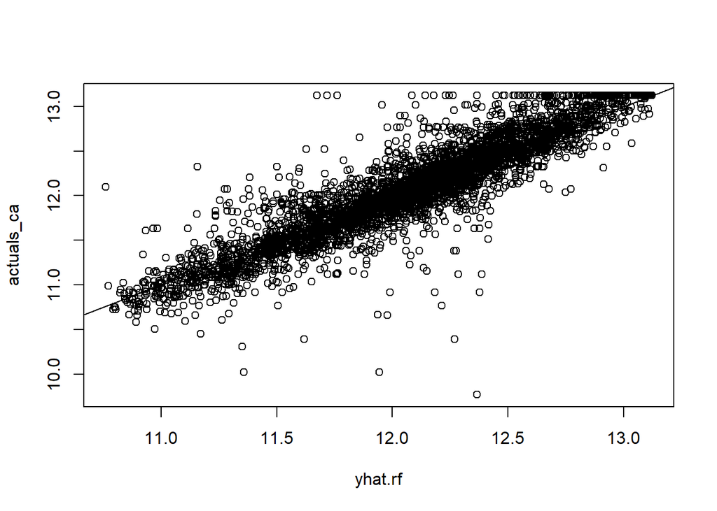

```r
## Random forest
ca_data = read.csv("CAhousing.csv")
logMedVal <- log(ca_data$medianHouseValue)
ca_data_vf = data.frame(logMedVal,ca_data)

library(caret)
set.seed(4)
train <- createDataPartition(y=ca_data_vf$logMedVal,p=0.8,list=FALSE)
train_data_ca <- ca_data_vf[train,]
test_data_ca <- ca_data_vf[-train,]

rf.ca =randomForest(logMedVal~.,data=train_data_ca[,-10],mtry=5, importance =TRUE)
actuals_ca = test_data_ca$logMedVal
yhat.rf = predict (rf.ca,newdata = test_data_ca)
plot(yhat.rf , actuals_ca)
abline (0,1)
```

```r
rmse.rf.ca = sqrt(mean(( yhat.rf - actuals_ca)^2))
rmse.rf.ca
```

```
## [1] 0.2338503
```

```r
## BART
library(BART)
x = ca_data_vf[,-c(1,10)] #rm=number of rooms and lstat= percent lower status
y = ca_data_vf$logMedVal # median value

n=length(y) #total sample size
set.seed(4) #
ii = sample(1:n,floor(.75*n)) # indices for train data, 75% of data
xtrain=x[ii,]; ytrain=y[ii] # training data
xtest=x[-ii,]; ytest=y[-ii] # test data
cat("train sample size is ",length(ytrain)," and test sample size is ",length(ytest),"\n")
```

```
## train sample size is  15480  and test sample size is  5160
```

```r
set.seed(4)
bf_train = wbart(xtrain,ytrain)
```

[output not shown]

```r
yhat = predict(bf_train,as.matrix(xtest))
```

```
## *****In main of C++ for bart prediction
## tc (threadcount): 1
## number of bart draws: 1000
## number of trees in bart sum: 200
## number of x columns: 8
## from x,np,p: 8, 5160
## ***using serial code
```

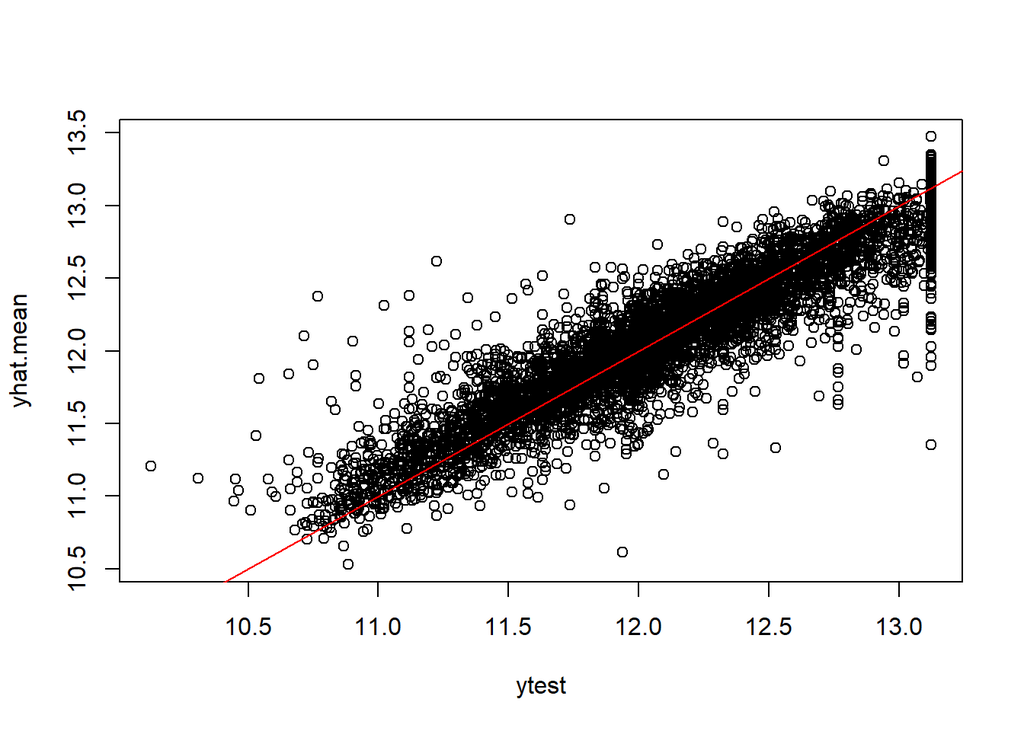

```r
yhat.mean = apply(yhat,2,mean)

plot(ytest,yhat.mean)
abline(0,1,col=2)
```

```r
rmse.bart.ca = sqrt(mean(yhat.mean - ytest))
rmse.bart.ca
```

```
## [1] 0.06230528
```

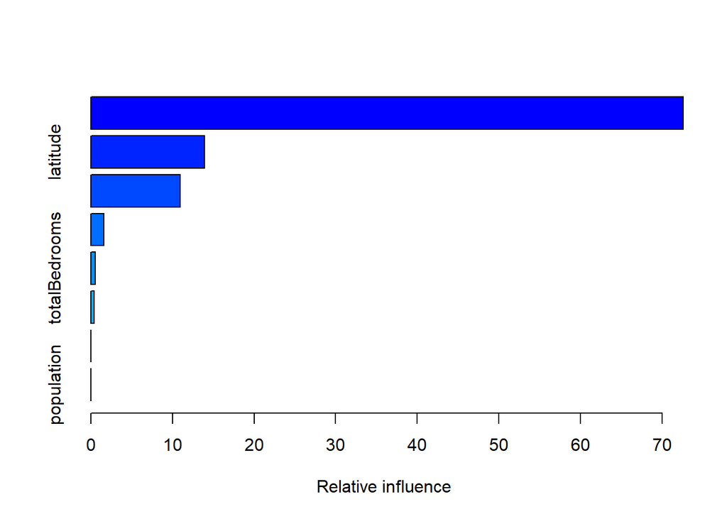

```
##                               var    rel.inf
## medianIncome         medianIncome 72.5946476
## latitude                 latitude 13.9243649
## longitude               longitude 10.9667763
## housingMedianAge housingMedianAge  1.6240496
## totalBedrooms       totalBedrooms  0.5136933
## households             households  0.3764684
## totalRooms             totalRooms  0.0000000
## population             population  0.0000000
```

```r
##########
## Boosting
##########
library (gbm)
set.seed (42)
boost.ca =gbm(logMedVal~.,data=train_data_ca[,-10], distribution="gaussian",n.trees =1000,shrinkage = 0.01)
summary(boost.ca)
```

```r
yhat.boost=predict (boost.ca ,newdata = test_data_ca,n.trees =1000,type = 'response')
rmse.boosting.ca = sqrt(mean(( yhat.boost - actuals_ca)^2))
rmse.boosting.ca
```

```
## [1] 0.3613288
```

### Problem 5: Neural Nets

```r
library (MASS)
data(Boston)
attach(Boston)
# Standardize the independent variables:
minv = rep(0,13)
maxv = rep(0,13)
Boston_copy = Boston

for (i in 1:13) {
 minv[i] = min(Boston[[i]])
 maxv[i] = max(Boston[[i]])
 Boston_copy[[i]] = (Boston[[i]]-minv[i])/(maxv[i]-minv[i])
}

library(nnet)
set.seed(99)
Bnn1 = nnet(log(medv)~.,Boston_copy,size=3,decay=.1,linout=T,maxit=350)
Bnn2 = nnet(log(medv)~.,Boston_copy,size=3,decay=.1,linout=T,maxit=20)
Bnn3 = nnet(log(medv)~.,Boston_copy,size=3,decay=.0001,linout=T,maxit=350)
Bnn4 = nnet(log(medv)~.,Boston_copy,size=3,decay=.6,linout=T,maxit=350)
Bnn5 = nnet(log(medv)~.,Boston_copy,size=10,decay=.1,linout=T,maxit=350)
Bnn_predict1 = predict(Bnn1,Boston_copy)
Bnn_predict2 = predict(Bnn2,Boston_copy)
Bnn_predict3 = predict(Bnn3,Boston_copy)
Bnn_predict4 = predict(Bnn4,Boston_copy)
Bnn_predict5 = predict(Bnn5,Boston_copy)

rmse_nn1 = sqrt(mean((Bnn_predict1 - log(medv))^2))
rmse_nn2 = sqrt(mean((Bnn_predict2 - log(medv))^2))
rmse_nn3 = sqrt(mean((Bnn_predict3 - log(medv))^2))
rmse_nn4 = sqrt(mean((Bnn_predict4 - log(medv))^2))
rmse_nn5 = sqrt(mean((Bnn_predict5 - log(medv))^2))

rmse_nn1
```

```
## [1] 0.1614931
```

```r
rmse_nn2
```

```
## [1] 0.1875672
```

```r
rmse_nn3
```

```
## [1] 0.1395757
```

```r
rmse_nn4
```

```
## [1] 0.189835
```

```r
rmse_nn5
```

```
## [1] 0.1495365
```

### Problem 6 : Describe your contribution to the project

#### Leadership

- With the help of my previous work experience, i was able to guide the team towards the right approach to solve the problem. I made sure that the work that was being done was organized and structured so that there was no redundancy while performing multiple tasks.
- Apart from that, i played a key role in distributing the work among the team members to maintain the speed and made sure that we learnt from each others strengths.I encouraged the team members to ask for help and identify their own weaknesses.

#### Analysis

- With respect to model building, i have designed the EDA steps for the project with the help of the other team members and ran iterations on models like logistic regression, random forests, Lasso regression to apply the learnings from the class onto the project.
- Collaboration on sharing the insights and the code on Google sheets was my idea to successfully complete the project without any obstacles.

#### Presentation

- With respect to the story flow of the presentation, i suggested some key points like executive summary,talking headers, simplicity/brevity of the slides to convey the right information in the right amount of time.